# outlier제거(IQR3기준, 최소화) 및 지역별, 연도별 평단가 분산분석 + 다중회귀분석(종속변수 SalePrice)

Author

2023-2학기 통계자료분석 1조 김재현

Published

December 6, 2023

Modified

December 23, 2023

## 데이터 불러오기 및 변수 정리

```r
# 데이터 불러오기

rawdata = read_excel("./Team_Assignment/Reyeme2.xls")
data1 = as.data.frame(rawdata)
data1$FirstDate = as.Date(as.numeric(as.character(data1$FirstDate)),origin="1899-12-30")
data1$RC = as.factor(data1$RC)
data1$Area = as.factor(data1$Area)
```

```r
# 데이터 변수 클래스 확인

str(data1)
```

```
'data.frame':   456 obs. of  17 variables:
 $ Address  : chr  "73 Allston St" "239 Allston St" "83 Amory St" "107 Antrim St" ...
 $ Unit     : chr  "1" "2" "3" "1" ...
 $ Area     : Factor w/ 16 levels "AG","AH","C",..: 4 4 9 9 9 9 9 9 9 9 ...
 $ AreaCode : num  4 4 9 9 9 9 9 9 9 9 ...
 $ Price1   : num  109000 127000 123000 219000 199000 ...
 $ Price2   : num  109000 127000 100000 210000 189000 ...
 $ SalePrice: num  106000 125000 95000 206000 175000 ...
 $ FirstDate: Date, format: "1993-07-17" "1993-08-21" ...
 $ CloseDate: POSIXct, format: "1993-10-22" "1993-10-22" ...
 $ Days     : num  97 62 208 159 110 116 160 80 157 123 ...
 $ Interior : num  834 850 730 1460 1630 ...
 $ Bed      : num  2 2 2 3 4 2 2 3 3 3 ...
 $ Bath     : num  1 1 1 2 1 1 1 1 1 1 ...
 $ Rooms    : num  4 5 4 6 8 6 6 5 6 6 ...
 $ Condo    : num  70 100 185 100 50 100 100 163 150 100 ...
 $ Tax      : num  490 923 575 1582 1659 ...
 $ RC       : Factor w/ 2 levels "0","1": 1 2 1 2 2 2 2 1 2 2 ...
```

```r
# 결측값 존재 확인

sum(is.na(data1))
```

```
[1] 9
```

**Note**

결측값 9개 존재.

```r
# 결측값 있는 행 확인

which(rowSums(is.na(data1)) > 0)
```

```
[1]  27 181 248 254 350 368 383 454 455
```

**Note**

결측값 중 한개를 제외하곤 모두 UNIT 열 값이다. UNIT는 건물내 특정 주거공간을 나타내는 호수(ex 101호, 102호)이다. Reyem Affiar가 구매하려는 건물의 UNIT는 주어져있지 않기 때문에 Reyem Affiar가 구매하려는 건물 가격을 추정하는데에 UNIT 변수는 사용하지 않을 것으로 예상한다. 나머지 한개의 결측값은 First Date에서 나타났으며, 254행에 있다. FirstDate열은 사용할 예정이므로 254행만 제외한다.

```r
#결측값 있는 행 중 254행 제거

data2 = data1[-254,]
```

```r
# data3 = data2의 Address 열 나누기

data3 <- separate(data2, Address, into = c("AddressNo", "AddressName", "Street"), sep = " ")
data3$AddressNo = as.factor(data3$AddressNo)
data3$AddressName = as.factor(data3$AddressName)
data3$Street = as.factor(data3$Street)
```

```r
#| label: First Date를 연 월 일로 열 나누기
# First Date를 연 월 일로 열 나누기

data4 <- separate(data3, FirstDate, into = c("YearF", "MonthF", "DateF"), sep = "-")
data4$YearF = as.factor(data4$YearF)
data4$MonthF = as.factor(data4$MonthF)
data4$DateF = as.factor(data4$DateF)
```

```r
#| label: 평단가 PrPerI 만들기
# 평단가 PrPerI 만들기

data4$PrPerI = data4$SalePrice/data4$Interior
```

```r
#| label: Bed/Rooms = BedPerR, Bath/Rooms = BathPerR 만들기

# Bed/Rooms = BedPerR, Bath/Rooms = BathPerR 만들기

data4$BedPerR  = data4$Bed/data4$Rooms
data4$BathPerR = data4$Bath/data4$Rooms
```

```r
str(data4)
```

```
'data.frame':   455 obs. of  24 variables:
 $ AddressNo  : Factor w/ 146 levels "1","10","10]",..: 128 57 133 6 8 19 139 97 19 18 ...
 $ AddressName: Factor w/ 112 levels "Allston","Amory",..: 1 1 2 3 3 3 3 3 3 3 ...
 $ Street     : Factor w/ 16 levels "Auburn","Ave",..: 14 14 14 14 14 14 14 14 14 14 ...
 $ Unit       : chr  "1" "2" "3" "1" ...
 $ Area       : Factor w/ 16 levels "AG","AH","C",..: 4 4 9 9 9 9 9 9 9 9 ...
 $ AreaCode   : num  4 4 9 9 9 9 9 9 9 9 ...
 $ Price1     : num  109000 127000 123000 219000 199000 ...
 $ Price2     : num  109000 127000 100000 210000 189000 ...
 $ SalePrice  : num  106000 125000 95000 206000 175000 ...
 $ YearF      : Factor w/ 8 levels "1920","1988",..: 7 7 7 5 6 6 6 7 7 7 ...
 $ MonthF     : Factor w/ 12 levels "01","02","03",..: 7 8 3 3 5 5 8 5 6 9 ...
 $ DateF      : Factor w/ 31 levels "01","02","03",..: 17 21 6 17 28 30 8 18 19 24 ...
 $ CloseDate  : POSIXct, format: "1993-10-22" "1993-10-22" ...
 $ Days       : num  97 62 208 159 110 116 160 80 157 123 ...
 $ Interior   : num  834 850 730 1460 1630 ...
 $ Bed        : num  2 2 2 3 4 2 2 3 3 3 ...
 $ Bath       : num  1 1 1 2 1 1 1 1 1 1 ...
 $ Rooms      : num  4 5 4 6 8 6 6 5 6 6 ...
 $ Condo      : num  70 100 185 100 50 100 100 163 150 100 ...
 $ Tax        : num  490 923 575 1582 1659 ...
 $ RC         : Factor w/ 2 levels "0","1": 1 2 1 2 2 2 2 1 2 2 ...
 $ PrPerI     : num  127 147 130 141 107 ...
 $ BedPerR    : num  0.5 0.4 0.5 0.5 0.5 ...
 $ BathPerR   : num  0.25 0.2 0.25 0.333 0.125 ...
```

## outlier 제거

### 1. FirstDate에서 Year가 너무 다른 데이터 삭제

```r
# YearF(FirstDate에서 연도만 추출) factor의 수준 확인
levels(data4$YearF)
```

```
[1] "1920" "1988" "1989" "1990" "1991" "1992" "1993" "1994"
```

```r
# YearF 변수에서 1920년 매매 자료 확인
outliers_YearF = data4$Days[data4$YearF=="1920"]
outliers_YearF
```

```
[1] 113
```

```r
# YearF 변수에서 1920년 매매 자료 제거(data7)
outliers_YearF_index = which(data4$YearF=="1920")
data5 = data4[-outliers_YearF_index,]
```

1개 제거

### 2. 너무 크거나 작은 면적(Interior) 제거

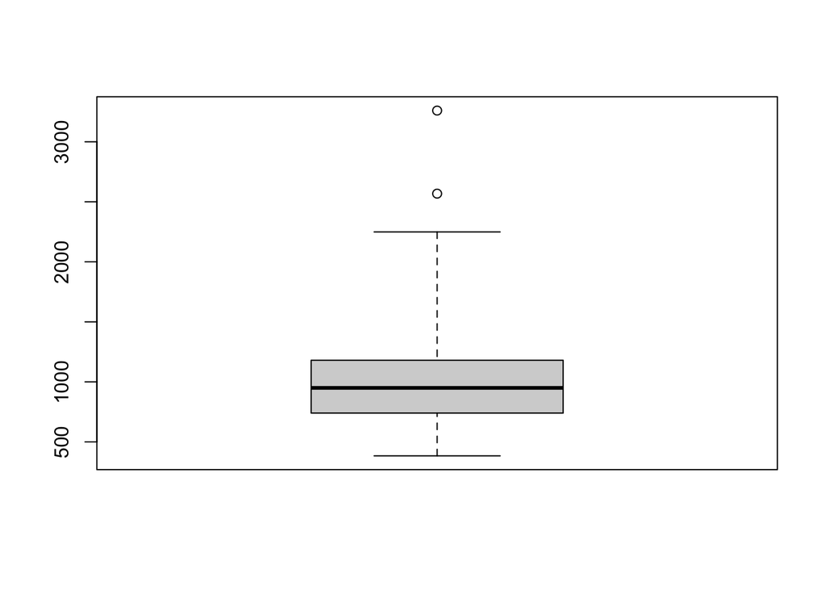

```r
# Interior변수의 boxplot 확인

boxplot(data5$Interior,range = 3)
```

```r
# Interior변수에서 3 IQR을 넘는 극단값 확인
Lo = quantile(data5$Interior,0.25)-3*IQR(data5$Interior)
Up = quantile(data5$Interior,0.75)+3*IQR(data5$Interior)
outliers_int =data5$Interior[(data5$Interior<Lo) | (data5$Interior>Up)]
outliers_int
```

```
[1] 2568 3260
```

```r
# Interior변수 극단값의 인덱스 추출 및 제거(data8)
outliers_int_index = which((data5$Interior<Lo) | (data5$Interior>Up))
data6 = data5[-outliers_int_index,]
```

2개 제거

### 3. 너무 크거나 작은 Tax 제거

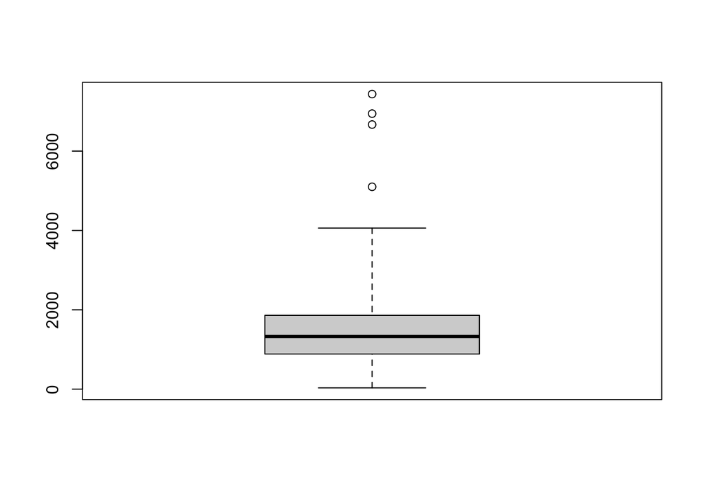

```r
# Tax 변수의 boxplot 확인

boxplot(data6$Tax,range=3)
```

```r
# Tax변수에서 3 IQR을 넘는 극단값 확인

Lo = quantile(data6$Tax,0.25)-3*IQR(data6$Tax)
Up = quantile(data6$Tax,0.75)+3*IQR(data6$Tax)
outliers_tax =data6$Tax[(data6$Tax<Lo) | (data6$Tax>Up)]
outliers_tax
```

```
[1] 5100 6669 6944 7437
```

```r
# Tax변수 극단값의 인덱스 추출 및 제거(dataA)

outliers_tax_index = which((data6$Tax<Lo) | (data6$Tax>Up))
data7 = data6[-outliers_tax_index,]
```

4개 제거

### 4. 너무 크거나 작은 Condo 제거

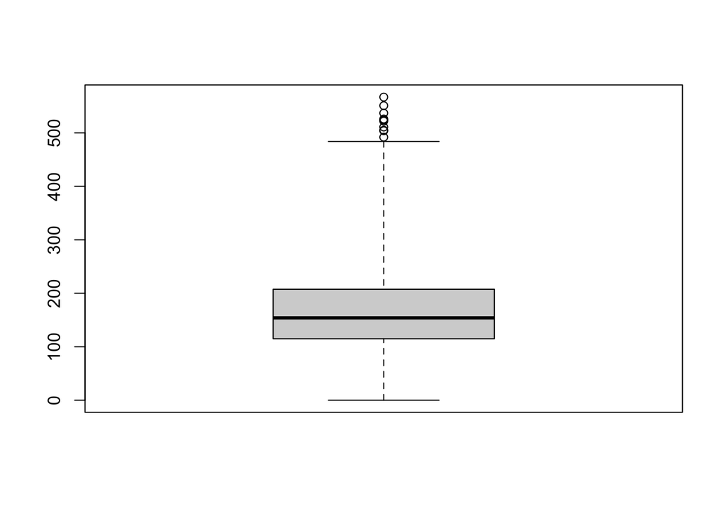

```r
# Condo 변수의 boxplot 확인

boxplot(data7$Condo,range =3)
```

```r
# Condo변수에서 3 IQR을 넘는 극단값 확인


Lo = quantile(data7$Condo,0.25)-3*IQR(data7$Condo)
Up = quantile(data7$Condo,0.75)+3*IQR(data7$Condo)
outliers_Condo =data7$Condo[(data7$Condo<Lo) | (data7$Condo>Up)]
outliers_Condo
```

```
 [1] 524 537 492 511 505 522 504 551 526 567
```

```r
# Condo변수 극단값의 인덱스 추출 및 제거(dataB)


outliers_Condo_index = which((data7$Condo<Lo) | (data7$Condo>Up))
data8 = data7[-outliers_Condo_index,]
```

10개 제거

### 5. 너무 많거나 적은 Rooms 제거

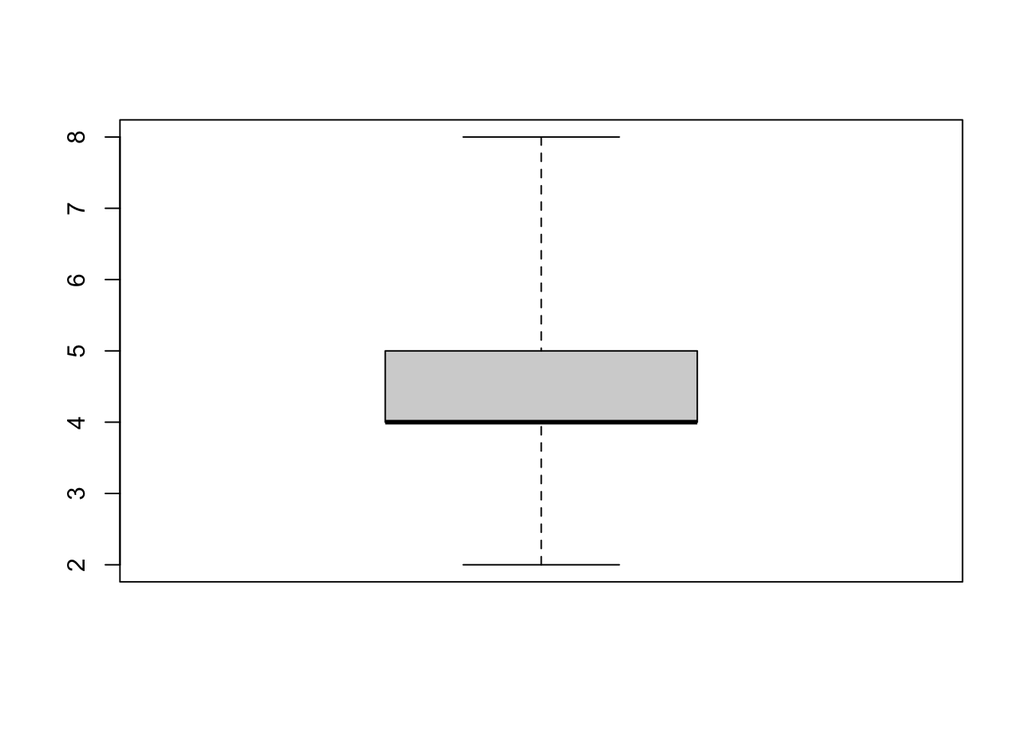

```r
# Rooms 변수의 boxplot 확인

boxplot(data8$Rooms,range = 3)
```

아웃라이어 보이지 않음 제거 x

### 6. 너무 많거나 적은 BED/Rooms = BedPerR 제거

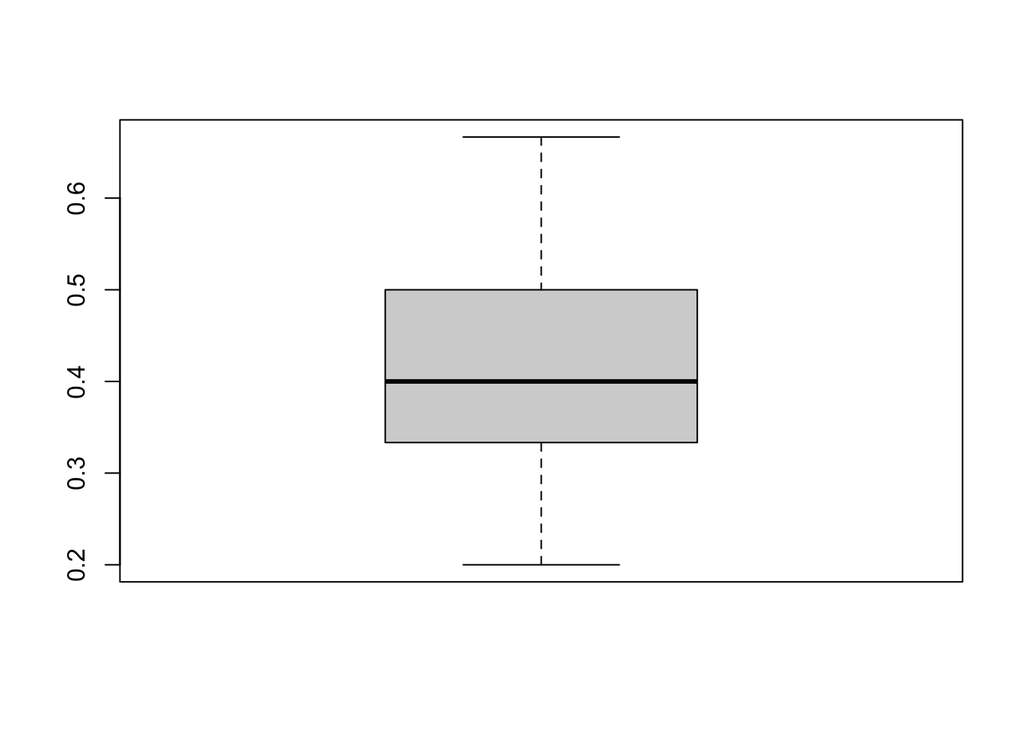

```r
# BedPerR 변수의 boxplot 확인

boxplot(data8$BedPerR, range = 3)
```

아웃라이어 보이지 않음 제거 x

### 7. 너무 많거나 적은 BATH/Rooms 제거

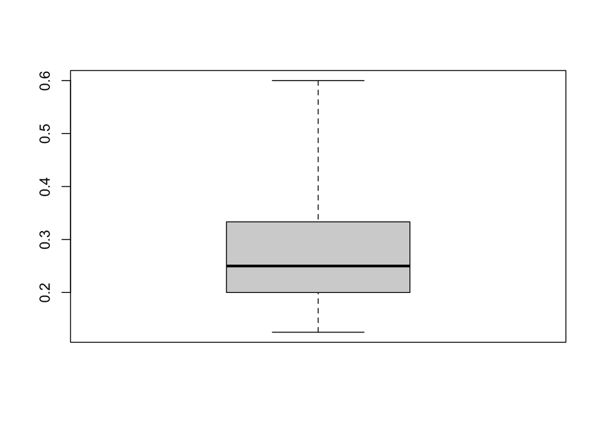

```r
# BathPerR 변수의 boxplot 확인

boxplot(data8$BathPerR,range = 3)
```

아웃라이어 보이지 않음 제거 x

### 8. Days가 너무 긴 혹은 짧은 데이터 삭제

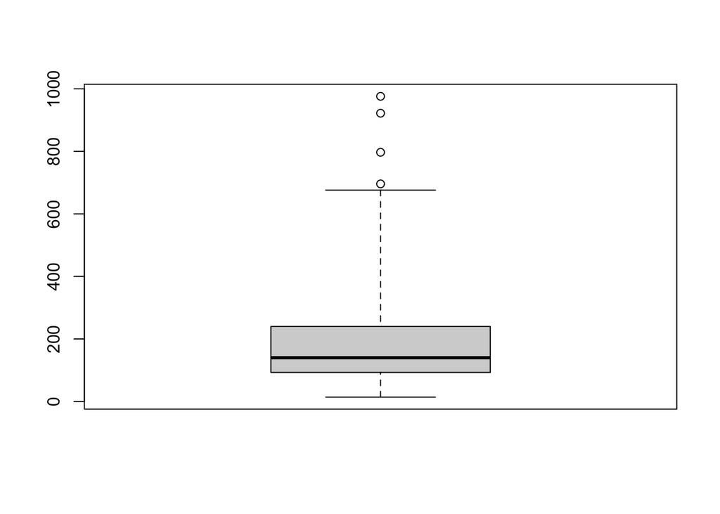

```r
# Days변수의 boxplot 확인
boxplot(data5$Days, range = 3)
```

```r
# Days변수에서 3 IQR을 넘는 극단값 확인
Lo = quantile(data8$Days,0.25)-3*IQR(data8$Days)
Up = quantile(data8$Days,0.75)+3*IQR(data8$Days)
outliers_days =data8$Days[(data8$Days<Lo) | (data8$Days>Up)]
outliers_days
```

```
[1] 676 922 976 797 696
```

```r
# Days변수 극단값의 인덱스 추출 및 제거
outliers_days_index = which((data8$Days<Lo) | (data8$Days>Up))
data9 = data8[-outliers_days_index,]
```

5개 제거

### 9. Area 수준별 갯수 확인 5개 미만일경우 제거

```r
# Area factor의 수준별 빈도수 확인
table(data9$Area)
```

```
 AG  AH   C  CP   E  FP  HS   K   M   N  NW  PS  RA  RS  SH   W
 11  34   4  22  27   2  79  17 111  15   5  15  37  14   6  34
```

C,FP

```r
# Area변수에서 C,FP만 뽑아내기

outliers_area =data9$Area[(data9$Area=="C") | (data9$Area=="FP")]
outliers_area
```

```
[1] C  C  FP FP C  C
Levels: AG AH C CP E FP HS K M N NW PS RA RS SH W
```

```r
# Area변수 C,FP 인덱스 추출 및 제거
outliers_area_index = which((data9$Area=="C") | (data9$Area=="FP"))

dataA = data9[-outliers_area_index,]
```

6개 제거

### 10. RC 0,1 갯수 확인 (한쪽이 너무 적으면 제거)

```r
# RC factor의 수준별 빈도수 확인

table(data9$RC)
```

```
  0   1
156 277
```

둘다 100개 이상의 데이터를 갖고 있으므로 한쪽 제거 안함

### 11. SalePrice ~ Area 분산분석 모형에서 IQR 3이상 극단값

```r
# dataA를 이용한 분산분석 모형 M1(SalePrice ~ Area)
M1 = aov(SalePrice ~ Area, dataA)
ri = M1$residuals
```

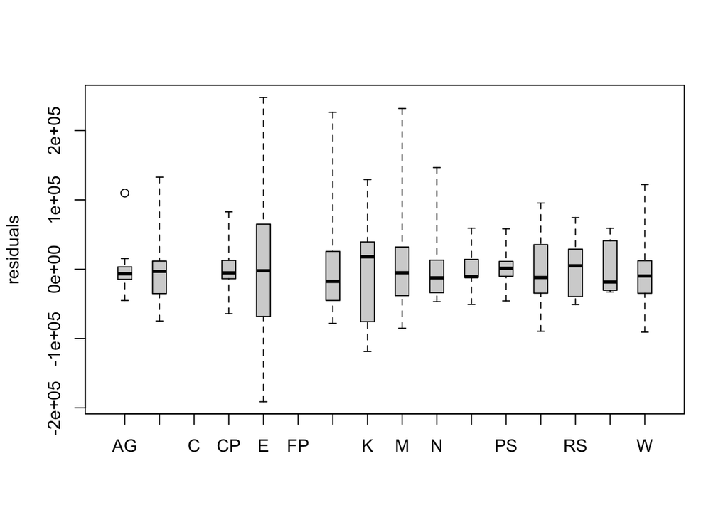

```r
# M1(dataA) outlier 확인(boxplot IQR3)
bp =boxplot(ri ~ dataA$Area, xlab = "", ylab = "residuals", range= 3, boxwex = 0.4) # boxwex는 상자폭을 0.4배 줄이는 옵션
```

```r
# boxplot에서 극단값 인덱스 반환
outliers = bp$out
outliers
```

```
     452
109863.6
```

```r
# ri 극단값의 인덱스 추출 및 제거
outliers_index = 423
dataB = dataA[-outliers_index,]
```

1개 데이터 제거

### outlier 제거 결과

**Note**

결과적으로 총 426개 관측치의 아래와 같은 데이터만 남았다.

```r
head(dataB)
```

```
  AddressNo AddressName Street Unit Area AreaCode Price1 Price2 SalePrice YearF
1        73     Allston     St    1   CP        4 109000 109000    106000  1993
2       239     Allston     St    2   CP        4 127000 127000    125000  1993
3        83       Amory     St    3    M        9 123000 100000     95000  1993
4       107      Antrim     St    1    M        9 219000 210000    206000  1991
5       109      Antrim     St    3    M        9 199000 189000    175000  1992
6       135      Antrim     St    1    M        9 169000 152000    136500  1992
  MonthF DateF  CloseDate Days Interior Bed Bath Rooms Condo  Tax RC   PrPerI
1     07    17 1993-10-22   97      834   2    1     4    70  490  0 127.0983
2     08    21 1993-10-22   62      850   2    1     5   100  923  1 147.0588
3     03    06 1993-09-30  208      730   2    1     4   185  575  0 130.1370
4     03    17 1991-08-23  159     1460   3    2     6   100 1582  1 141.0959
5     05    28 1992-09-15  110     1630   4    1     8    50 1659  1 107.3620
6     05    30 1992-09-23  116     1225   2    1     6   100 1698  1 111.4286
    BedPerR  BathPerR
1 0.5000000 0.2500000
2 0.4000000 0.2000000
3 0.5000000 0.2500000
4 0.5000000 0.3333333
5 0.5000000 0.1250000
6 0.3333333 0.1666667
```

## SalePrice ~ Area 분산분석(dataD)

```r
# Area 변수 수준별 빈도수 확인

table(dataB$Area)
```

```
 AG  AH   C  CP   E  FP  HS   K   M   N  NW  PS  RA  RS  SH   W
 10  34   0  22  27   0  79  17 111  15   5  15  37  14   6  34
```

```r
# dataB를 이용한 분산분석 M2(SalePrice ~ Area) 정의

M2 = aov(SalePrice ~ Area, dataB)
anova(M2)
```

```
Analysis of Variance Table

Response: SalePrice
           Df     Sum Sq    Mean Sq F value    Pr(>F)
Area       13 3.5564e+11 2.7357e+10  7.3324 5.534e-13 ***
Residuals 412 1.5371e+12 3.7309e+09
---
Signif. codes:  0 '***' 0.001 '**' 0.01 '*' 0.05 '.' 0.1 ' ' 1
```

Area의 모든 평균이 같다는 귀무가설을 기각했다.

등분산성을 확인해보면..

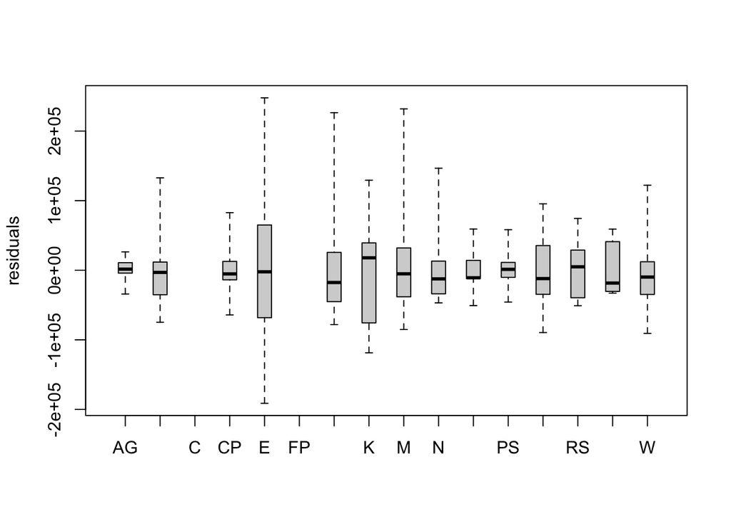

```r
ri = M2$residuals
boxplot(ri ~ dataB$Area, xlab = "", ylab = "residuals", range= 3, boxwex = 0.4) # boxwex는 상자폭을 0.4배 줄이는 옵션
```

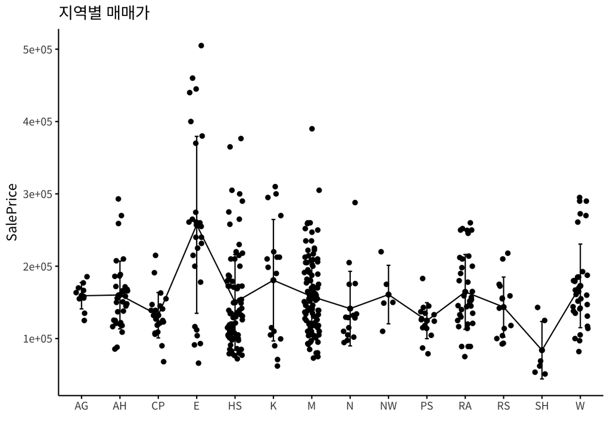

```r
ggpubr::ggline(dataB, x = "Area", y = "SalePrice", add = c("mean_sd", "jitter"),
       title = "지역별 매매가", ylab ="SalePrice", xlab = "", ggtheme = theme_classic(base_family = "Noto Sans KR") )
```

Area별로 분포가 크게 다른 것으로 보아 등분산성을 만족하지 않는 것으로 보인다.

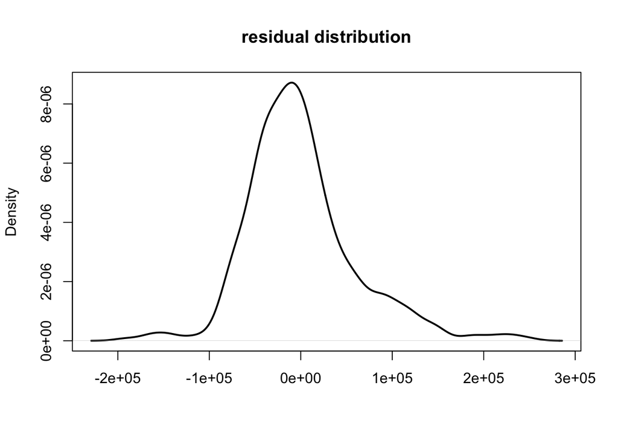

```r
plot(density(M2$residuals),xlab = "",main = "residual distribution", lwd = 2)
```

잔차의 분포가 상당히 정규성을 띄는 분포를 보인다.

그러므로 bartlett test를 이용하여 등분산성을 검정한다.

```r
bartlett.test(SalePrice ~ Area, dataB)
```

```
    Bartlett test of homogeneity of variances

data:  SalePrice by Area
Bartlett's K-squared = 100.32, df = 13, p-value = 1.436e-15
```

p값이(`1.436e-15`) 등분산성을 만족한다는 귀무가설을 기각하고 있기 때문에 등분산성을 갖고 있다고 볼 수 없다.

때문에 비모수검정을 진행한다.

### 비모수검정

```r
kruskal.test(SalePrice ~ Area, dataB)
```

```
    Kruskal-Wallis rank sum test

data:  SalePrice by Area
Kruskal-Wallis chi-squared = 50.738, df = 13, p-value = 2.226e-06
```

p-value가 매우 작으므로 그룹간 차이가 존재하는 것으로 판단할 수 있다.

사후검정, 다중비교를 진행한다. 작은 차이라도 찾아내기 위해 fisher lsd 검정과 같이 개별 유의수준을 통제하는 방식으로 wilcoxon 검정을 사용한다.

```r
# dataD Wilcoxon 검정 - 다중 비교 사후검정 (순위기반)

pairwise.wilcox.test(dataB$SalePrice, dataB$Area, p.adjust.method = "none")
```

```
    Pairwise comparisons using Wilcoxon rank sum test with continuity correction

data:  dataB$SalePrice and dataB$Area

   AG      AH      CP      E       HS      K       M       N       NW
AH 0.65403 -       -       -       -       -       -       -       -
CP 0.00534 0.01605 -       -       -       -       -       -       -
E  0.01194 0.00114 0.00037 -       -       -       -       -       -
HS 0.11148 0.06079 0.81459 5.0e-05 -       -       -       -       -
K  0.46652 0.44165 0.22319 0.04046 0.23207 -       -       -       -
M  0.50688 0.69331 0.03038 3.1e-05 0.05006 0.38584 -       -       -
N  0.06228 0.09698 0.95066 0.00388 0.74890 0.28164 0.12617 -       -
NW 0.76790 0.89969 0.08597 0.06166 0.27696 0.81402 0.75452 0.22135 -
PS 0.00228 0.00418 0.47670 0.00103 0.43564 0.16802 0.01161 0.75571 0.05263
RA 0.76495 0.83584 0.01268 0.00095 0.04098 0.62817 0.49664 0.06030 1.00000
RS 0.22980 0.30197 0.53745 0.00189 0.83404 0.26628 0.37002 0.82724 0.45870
SH 0.00338 0.00215 0.02893 0.00163 0.00888 0.01422 0.00201 0.02926 0.01732
W  0.75796 0.45059 0.00370 0.00839 0.01352 0.63147 0.20097 0.02272 0.78475
   PS      RA      RS      SH
AH -       -       -       -
CP -       -       -       -
E  -       -       -       -
HS -       -       -       -
K  -       -       -       -
M  -       -       -       -
N  -       -       -       -
NW -       -       -       -
PS -       -       -       -
RA 0.00387 -       -       -
RS 0.31541 0.26774 -       -
SH 0.05155 0.00181 0.01538 -
W  0.00127 0.53797 0.11747 0.00137

P value adjustment method: none
```

wilcoxon 검정을 기반으로 두 변수간 p값이 0.1 이하인 경우 붉은 타일이 나타나도록 했다.

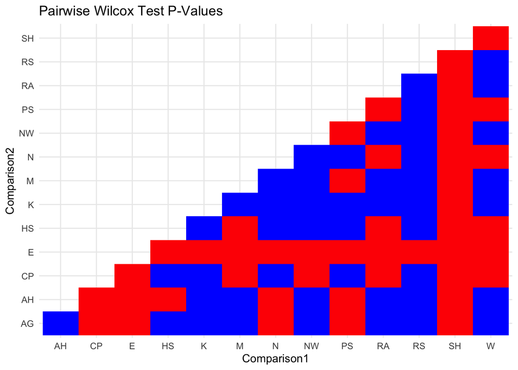

```r
# Area 변수의 순서를 변경한 dataC

dataC = dataB
# Area 변수의 순서를 변경
dataC$Area <- factor(dataB$Area, levels = c("E","K","W","RA","AG","AH","NW","M","HS","RS","N","CP","PS","SH"))
```

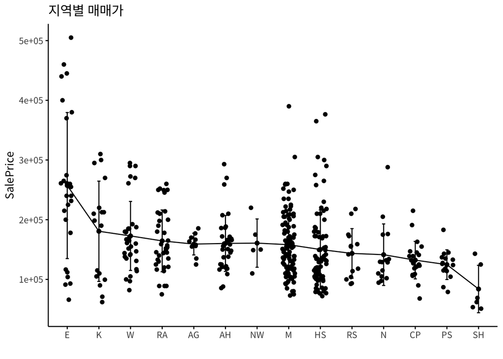

### Area 분산분석 결과

1Zone = “E”  
2Zone = “K”,“W”,“RA”,“AG”,“AH”,“NW” 3Zone = “M”  
4Zone = “HS”,“RS”,“N”,“CP”,“PS” 5Zone = “SH”

```r
# Zone 변수 추가한 dataD

dataD = dataC
for(i in 1:nrow(dataD)){
  if(dataD$Area[i] == "E"){
    dataD$Zone[i] = "1Zone"
    }
  else if(dataD$Area[i] == "K"|dataD$Area[i] == "W"|dataD$Area[i] == "RA"|dataD$Area[i] == "AG"|dataD$Area[i] == "AH"|dataD$Area[i] == "NW"){
    dataD$Zone[i] = "2Zone"
    }
  else if(dataD$Area[i] == "M"){
    dataD$Zone[i] = "3Zone"
    }
  else if(dataD$Area[i] == "HS"|dataD$Area[i] == "RS"|dataD$Area[i] == "N"|dataD$Area[i] == "CP"|dataD$Area[i] == "PS"){
    dataD$Zone[i] = "4Zone"
    }
  else if(dataD$Area[i] == "SH"){
    dataD$Zone[i] = "5Zone"
    }
}
dataD$Zone = as.factor(dataD$Zone)
```

```r
head(dataD)
```

```
  AddressNo AddressName Street Unit Area AreaCode Price1 Price2 SalePrice YearF
1        73     Allston     St    1   CP        4 109000 109000    106000  1993
2       239     Allston     St    2   CP        4 127000 127000    125000  1993
3        83       Amory     St    3    M        9 123000 100000     95000  1993
4       107      Antrim     St    1    M        9 219000 210000    206000  1991
5       109      Antrim     St    3    M        9 199000 189000    175000  1992
6       135      Antrim     St    1    M        9 169000 152000    136500  1992
  MonthF DateF  CloseDate Days Interior Bed Bath Rooms Condo  Tax RC   PrPerI
1     07    17 1993-10-22   97      834   2    1     4    70  490  0 127.0983
2     08    21 1993-10-22   62      850   2    1     5   100  923  1 147.0588
3     03    06 1993-09-30  208      730   2    1     4   185  575  0 130.1370
4     03    17 1991-08-23  159     1460   3    2     6   100 1582  1 141.0959
5     05    28 1992-09-15  110     1630   4    1     8    50 1659  1 107.3620
6     05    30 1992-09-23  116     1225   2    1     6   100 1698  1 111.4286
    BedPerR  BathPerR  Zone
1 0.5000000 0.2500000 4Zone
2 0.4000000 0.2000000 4Zone
3 0.5000000 0.2500000 3Zone
4 0.5000000 0.3333333 3Zone
5 0.5000000 0.1250000 3Zone
6 0.3333333 0.1666667 3Zone
```

## SalePrice ~ YearF 분산분석(dataF)

```r
# dataD를 이용한 SalePrice ~ YearF분산분석 M3 정의


M3 = aov(SalePrice ~ YearF, dataD)
anova(M3)
```

```
Analysis of Variance Table

Response: SalePrice
           Df     Sum Sq    Mean Sq F value Pr(>F)
YearF       5 3.6544e+10 7308869734  1.6537 0.1447
Residuals 420 1.8562e+12 4419621515
```

YearF에 따른 SalePrice의 모든 평균이 같다는 귀무가설을 기각하지 못한다.

## HousePriceIndex사용

연도별 SalePrice의 변화가 통계적으로 유의미하지 않기 때문에 기간별 변화를 알 수 있는 HousePriceIndex를 사용하고자 한다.

All-Transactions House Price Index for Cambridge-Newton-Framingham, MA (MSAD)https://fred.stlouisfed.org/series/ATNHPIUS15764Q

quarter 기간별 자료이므로 quarter 열을 만들어준다.

```r
dataE = dataD
```

```r
# dataE의 연도 수준 확인

table(dataE$YearF)
```

```
1920 1988 1989 1990 1991 1992 1993 1994
   0    0   25   72   89  103  131    6
```

```r
# dataE에 quarter지정

for(i in 1:nrow(dataE)){
    if(dataE$YearF[i] == "1989"){
      if(dataE$MonthF[i] == "01"|dataE$MonthF[i] == "02"|dataE$MonthF[i] == "03"){
        dataE$Quarter[i] = "1989-1Q"
      }
      else if(dataE$MonthF[i] == "04"|dataE$MonthF[i] == "05"|dataE$MonthF[i] == "06"){
        dataE$Quarter[i] = "1989-2Q"
      }
      else if(dataE$MonthF[i] == "07"|dataE$MonthF[i] == "08"|dataE$MonthF[i] == "09"){
        dataE$Quarter[i] = "1989-3Q"
      }
      else if(dataE$MonthF[i] == "10"|dataE$MonthF[i] == "11"|dataE$MonthF[i] == "12"){
        dataE$Quarter[i] = "1989-4Q"
      }
    }
  else if(dataE$YearF[i] == "1990"){
    if(dataE$MonthF[i] == "01"|dataE$MonthF[i] == "02"|dataE$MonthF[i] == "03"){
        dataE$Quarter[i] = "1990-1Q"
      }
      else if(dataE$MonthF[i] == "04"|dataE$MonthF[i] == "05"|dataE$MonthF[i] == "06"){
        dataE$Quarter[i] = "1990-2Q"
      }
      else if(dataE$MonthF[i] == "07"|dataE$MonthF[i] == "08"|dataE$MonthF[i] == "09"){
        dataE$Quarter[i] = "1990-3Q"
      }
      else if(dataE$MonthF[i] == "10"|dataE$MonthF[i] == "11"|dataE$MonthF[i] == "12"){
        dataE$Quarter[i] = "1990-4Q"
      }
  }
  else if(dataE$YearF[i] == "1991"){
    if(dataE$MonthF[i] == "01"|dataE$MonthF[i] == "02"|dataE$MonthF[i] == "03"){
        dataE$Quarter[i] = "1991-1Q"
      }
      else if(dataE$MonthF[i] == "04"|dataE$MonthF[i] == "05"|dataE$MonthF[i] == "06"){
        dataE$Quarter[i] = "1991-2Q"
      }
      else if(dataE$MonthF[i] == "07"|dataE$MonthF[i] == "08"|dataE$MonthF[i] == "09"){
        dataE$Quarter[i] = "1991-3Q"
      }
      else if(dataE$MonthF[i] == "10"|dataE$MonthF[i] == "11"|dataE$MonthF[i] == "12"){
        dataE$Quarter[i] = "1991-4Q"
      }
  }
  else if(dataE$YearF[i] == "1992"){
    if(dataE$MonthF[i] == "01"|dataE$MonthF[i] == "02"|dataE$MonthF[i] == "03"){
        dataE$Quarter[i] = "1992-1Q"
      }
      else if(dataE$MonthF[i] == "04"|dataE$MonthF[i] == "05"|dataE$MonthF[i] == "06"){
        dataE$Quarter[i] = "1992-2Q"
      }
      else if(dataE$MonthF[i] == "07"|dataE$MonthF[i] == "08"|dataE$MonthF[i] == "09"){
        dataE$Quarter[i] = "1992-3Q"
      }
      else if(dataE$MonthF[i] == "10"|dataE$MonthF[i] == "11"|dataE$MonthF[i] == "12"){
        dataE$Quarter[i] = "1992-4Q"
      }
  }
  else if(dataE$YearF[i] == "1993"){
    if(dataE$MonthF[i] == "01"|dataE$MonthF[i] == "02"|dataE$MonthF[i] == "03"){
        dataE$Quarter[i] = "1993-1Q"
      }
      else if(dataE$MonthF[i] == "04"|dataE$MonthF[i] == "05"|dataE$MonthF[i] == "06"){
        dataE$Quarter[i] = "1993-2Q"
      }
      else if(dataE$MonthF[i] == "07"|dataE$MonthF[i] == "08"|dataE$MonthF[i] == "09"){
        dataE$Quarter[i] = "1993-3Q"
      }
      else if(dataE$MonthF[i] == "10"|dataE$MonthF[i] == "11"|dataE$MonthF[i] == "12"){
        dataE$Quarter[i] = "1993-4Q"
      }
  }
  else if(dataE$YearF[i] == "1994"){
    if(dataE$MonthF[i] == "01"|dataE$MonthF[i] == "02"|dataE$MonthF[i] == "03"){
        dataE$Quarter[i] = "1994-1Q"
      }
      else if(dataE$MonthF[i] == "04"|dataE$MonthF[i] == "05"|dataE$MonthF[i] == "06"){
        dataE$Quarter[i] = "1994-2Q"
      }
      else if(dataE$MonthF[i] == "07"|dataE$MonthF[i] == "08"|dataE$MonthF[i] == "09"){
        dataE$Quarter[i] = "1994-3Q"
      }
      else if(dataE$MonthF[i] == "10"|dataE$MonthF[i] == "11"|dataE$MonthF[i] == "12"){
        dataE$Quarter[i] = "1994-4Q"
      }
  }
}
dataE$Quarter = as.factor(dataE$Quarter)
```